# Principal Component Analysis

Dataset dados.trat

This dataset contains 18 individuals and 6 variables, 1 qualitative variable is considered as illustrative.

### 1. Study of the outliers

The analysis of the graphs does not detect any outlier.

### 2. Inertia distribution

The inertia of the first dimensions shows if there are strong relationships between variables and suggests the number of dimensions that should be studied.

The first two dimensions of analyse express **64.23%** of the total dataset inertia ; that means that 64.23% of the individuals (or variables) cloud total variability is explained by the plane. The inertia observed on the first plane is smaller than the reference value that equals **68.2%**, therefore low in comparison (the reference value is the 0.95-quantile of the inertia percentages distribution obtained by simulating 1566 data tables of equivalent size on the basis of a normal distribution). Moreover, the inertia projected on the first dimension is smaller than the reference value **42.23%**. The variability expressed by the analyse is thus **not** significant.

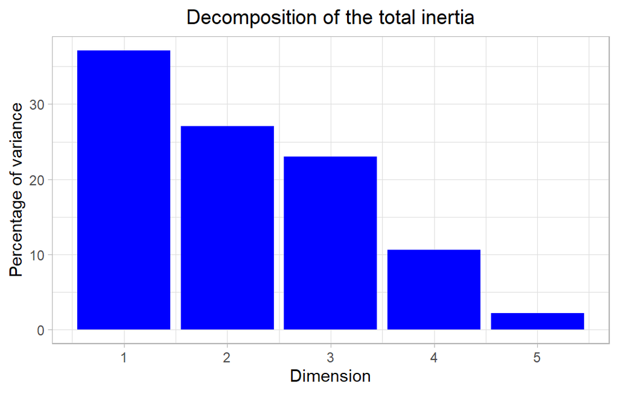

**Figure 2 - Decomposition of the total inertia**

An estimation of the right number of axis to interpret suggests to not interpret the analysis at all. Indeed, the amount of inertia of the first axis is not higher than that obtained by the 0.95-quantile of random distributions (37.17% against 42.23%). This observation suggests that no axis is carrying a real information. As a consequence, the description will stand to these axis.

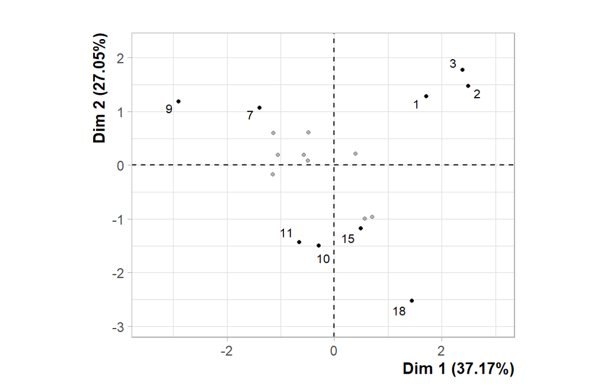

**Figure 3.1 - Individuals factor map (PCA)** *The labeled individuals are those with the higher contribution to the plane construction.*

The Wilks test p-value indicates which variable factors are the best separated on the plane (i.e. which one explain the best the distance between individuals).

```
## dados.trat[, 1]
##    2.075009e-07
```

There only is one possible qualitative variable to illustrate the distance between individuals : *dados.trat[, 1]*.

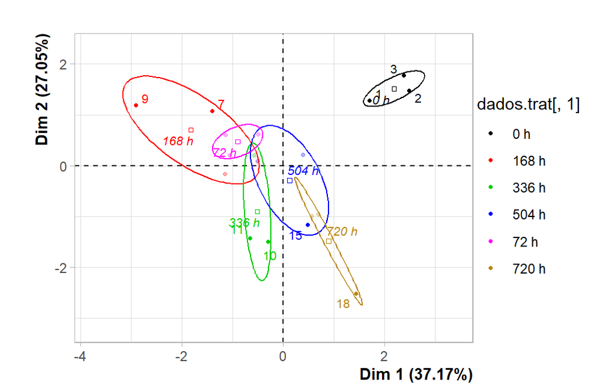

**Figure 3.2 - Individuals factor map (PCA)** *The labeled individuals are those with the higher contribution to the plane construction.* *The individuals are coloured after their category for the variable* dados.trat[, 1].

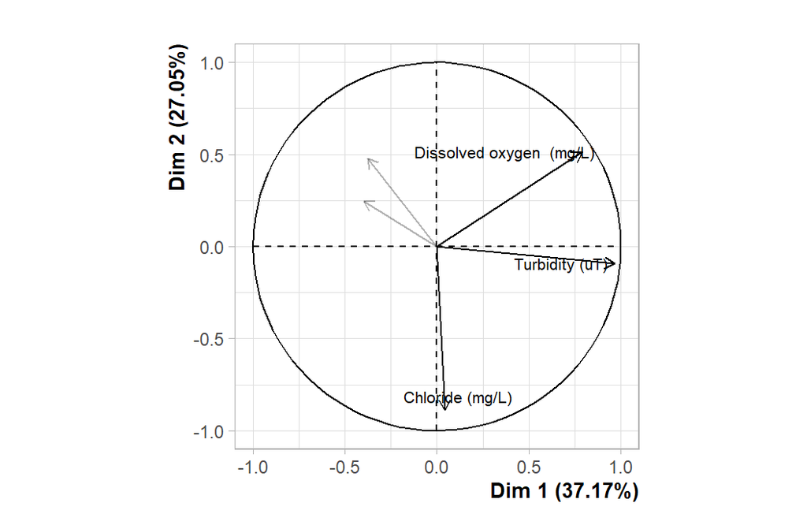

**Figure 3.3 - Variables factor map (PCA)** *The labeled variables are those the best shown on the plane.*

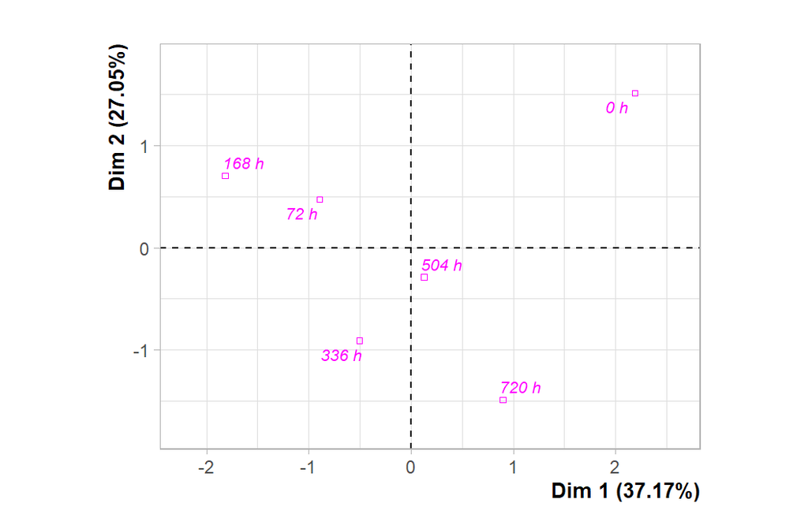

**Figure 3.4 - Qualitative factor map (PCA)** *The labeled factors are those the best shown on the plane.*

The **dimension 1** opposes individuals such as *2*, *1* and *3* (to the right of the graph, characterized by a strongly positive coordinate on the axis) to individuals such as *9* and *7* (to the left of the graph, characterized by a strongly negative coordinate on the axis).

The group in which the individuals *2*, *1* and *3* stand (characterized by a positive coordinate on the axis) is sharing :

- high values for the variables *Dissolved.oxygen..(mg/L)* and *Turbidity.(uT)* (variables are sorted from the strongest).

The group in which the individuals *9* and *7* stand (characterized by a negative coordinate on the axis) is sharing :

- low values for the variable *Turbidity.(uT)*.

The **dimension 2** opposes individuals such as *2*, *1*, *3*, *9* and *7* (to the top of the graph, characterized by a strongly positive coordinate on the axis) to individuals such as *15*, *18*, *10* and *11* (to the bottom of the graph, characterized by a strongly negative coordinate on the axis).

The group in which the individuals *9* and *7* stand (characterized by a positive coordinate on the axis) is sharing :

- low values for the variable *Turbidity.(uT)*.

The group in which the individuals *2*, *1* and *3* stand (characterized by a positive coordinate on the axis) is sharing :

- high values for the variables *Dissolved.oxygen..(mg/L)* and *Turbidity.(uT)* (variables are sorted from the strongest).

The group in which the individuals *15*, *18*, *10* and *11* stand (characterized by a negative coordinate on the axis) is sharing :

- high values for the variable *Chloride.(mg/L)*.
- low values for the variable *Dissolved.Organic.Carbon.(mg/L)*.

### 5. Classification

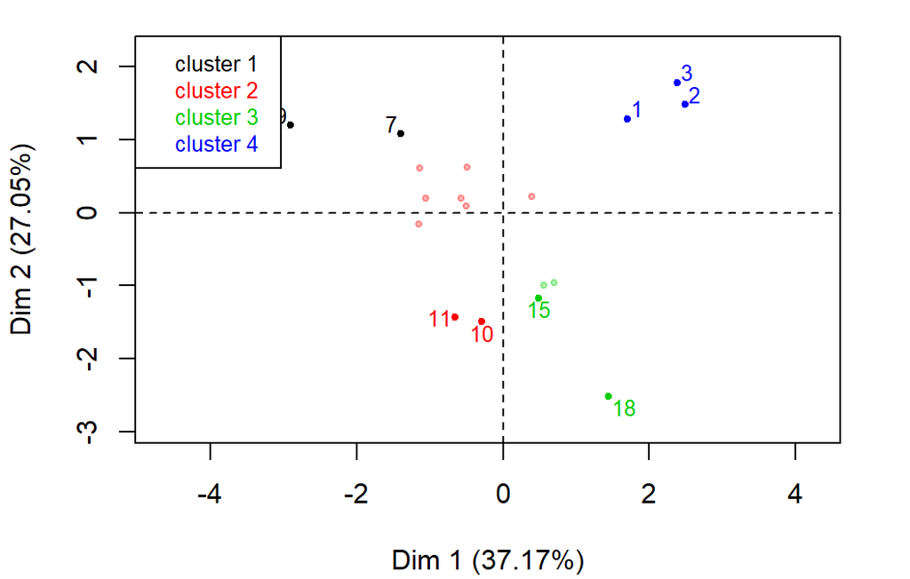

**Figure 5 - Ascending Hierarchical Classification of the individuals.** *The classification made on individuals reveals 4 clusters.*

The **cluster 1** is made of individuals such as *7* and *9*. This group is characterized by :

- high values for the variable *True.color.(uH)*.
- low values for the variable *Turbidity.(uT)*.

The **cluster 2** is made of individuals such as *10* and *11*. This group is characterized by :

- high values for the variable *Dissolved.Organic.Carbon.(mg/L)*.

The **cluster 3** is made of individuals such as *15* and *18*. This group is characterized by :

- low values for the variable *Dissolved.Organic.Carbon.(mg/L)*.

The **cluster 4** is made of individuals such as *1*, *2* and *3*. This group is characterized by :

- high values for the variables *Dissolved.oxygen..(mg/L)* and *Turbidity.(uT)* (variables are sorted from the strongest).

## Annexes

```r
dimdesc(res, axes = 1:0)
```

[output not shown]

[output cut: 20 more lines]

[output not shown]

**Figure 6 - List of variables characterizing the dimensions of the analysis.**

```r
res.hcpc$desc.var
```

```
Link between the cluster variable and the categorical variables (chi-square test)
=================================================================================
                     p.value df
dados.trat[,.1] 0.0001996813 15

Description of each cluster by the categories
=============================================
$`1`
                       Cla/Mod Mod/Cla   Global    p.value   v.test
dados.trat[,.1]=168 h 66.66667     100 16.66667 0.01960784 2.333769

$`2`
NULL

$`3`
                      Cla/Mod Mod/Cla   Global     p.value   v.test
dados.trat[,.1]=720 h     100      75 16.66667 0.004901961 2.813407

$`4`
                    Cla/Mod Mod/Cla   Global    p.value  v.test
dados.trat[,.1]=0 h     100     100 16.66667 0.00122549 3.23288


Link between the cluster variable and the quantitative variables
================================================================
                                     Eta2      P-value
True.color.(uH)                 0.8365338 9.071372e-06
Turbidity.(uT)                  0.8267413 1.356305e-05
Dissolved.oxygen..(mg/L)        0.7952423 4.295255e-05
Dissolved.Organic.Carbon.(mg/L) 0.7308938 2.807390e-04
Chloride.(mg/L)                 0.4199724 4.860686e-02

Description of each cluster by quantitative variables
=====================================================
$`1`
                   v.test Mean in category Overall mean sd in category Overall sd      p.value
True.color.(uH)  3.680169         124.0069    76.170022        1.88005  18.948465 0.0002330791
Turbidity.(uT)  -2.411089           2.2200     4.823889        0.73000   1.574305 0.0159049866

$`2`
                                  v.test Mean in category Overall mean sd in category Overall sd
Dissolved.Organic.Carbon.(mg/L) 2.682511         15.93333     14.33722       1.184155   2.453274
                                    p.value
Dissolved.Organic.Carbon.(mg/L) 0.007307173

$`3`
                                   v.test Mean in category Overall mean sd in category Overall sd
Dissolved.Organic.Carbon.(mg/L) -3.364062          10.5925     14.33722       1.793507   2.453274
                                    p.value
Dissolved.Organic.Carbon.(mg/L) 0.000768043

$`4`
                           v.test Mean in category Overall mean sd in category Overall sd
Dissolved.oxygen..(mg/L) 3.655700         7.800000     4.151111      1.1860298   1.840474
Turbidity.(uT)           2.591723         7.036667     4.823889      0.4977505   1.574305
                              p.value
Dissolved.oxygen..(mg/L) 0.0002564816
Turbidity.(uT)           0.0095496759
```

**Figure 7 - List of variables characterizing the clusters of the classification.**